# Foodie Fi

```python
from IPython.core.interactiveshell import InteractiveShell

InteractiveShell.ast_node_interactivity = "all"

import os
import sys

import matplotlib.pyplot as plt
import seaborn as sns

sys.path.append("../../../")
from src.athena import Athena
from src.utils import create_session
```

from IPython.core.interactiveshell import InteractiveShell InteractiveShell.ast_node_interactivity = "all" import os import sys import matplotlib.pyplot as plt import seaborn as sns sys.path.append("../../../") from src.athena import Athena from src.utils import create_session

## Global

```python
boto3_session = create_session(
    profile_name="dev",
    role_arn=os.getenv("ATHENA_IAM_ROLE_ARN"),
)

wait = True
ctas_approach = False

database = "foodie_fi"
tables = ["plans", "subscriptions"]
sql_path = "../sql/"

athena = Athena(boto3_session=boto3_session, s3_output=os.getenv("ATHENA_S3_OUTPUT"))
athena
```

boto3_session = create_session( profile_name="dev", role_arn=os.getenv("ATHENA_IAM_ROLE_ARN"), ) wait = True ctas_approach = False database = "foodie_fi" tables = ["plans", "subscriptions"] sql_path = "../sql/" athena = Athena(boto3_session=boto3_session, s3_output=os.getenv("ATHENA_S3_OUTPUT")) athena

```
Athena(boto3_session=Session(region_name='us-east-1'), s3_output=s3://sql-case-studies/query_results)
```

## Problem Statement

In 2020, Foodie-Fi was launched as a subscription-based streaming service focused exclusively on food-related content, offering customers unlimited access to on-demand cooking shows and videos. The service was built with a data-driven approach, aiming to leverage subscription and customer behavior data to guide strategic decisions, improve customer retention, and drive business growth.

This case study aims to analyze Foodie-Fi's subscription data to uncover insights into customer behaviors, subscription patterns, and revenue trends, helping the business make informed decisions on pricing, features, and customer engagement strategies.

## Entity Relationship Diagram

[figure not shown]

### Plans Table

The `plans` table outlines the subscription options available to Foodie-Fi customers. Each plan includes unique features, pricing, and accessibility:

- **Trial Plan**: A free 7-day trial available to all customers upon signup. After the trial, customers are automatically transitioned to the Pro Monthly plan unless they cancel or choose another plan.
- **Basic Monthly Plan**: Provides limited access to videos for $9.90 per month.
- **Pro Monthly Plan**: Offers unlimited streaming and the ability to download videos for $19.90 per month.
- **Pro Annual Plan**: Provides the same benefits as the Pro Monthly plan but at a discounted annual rate of $199.
- **Churn Plan**: Represents canceled subscriptions. Customers retain access until the end of the current billing period, but the plan price is recorded as null.

### Subscriptions Table

The `subscriptions` table captures customer subscription events and changes over time. It records the exact date when a customer transitions to a specific plan. Key behaviors reflected in this table include:

- **Downgrades or Cancellations**: If a customer cancels or downgrades from a higher plan, their current plan remains active until the billing period ends. The `start_date` indicates when the new plan becomes effective.
- **Upgrades**: If a customer upgrades their subscription (e.g., from Basic to Pro), the new plan takes effect immediately, and the `start_date` reflects this change.
- **Churn**: When a customer decides to cancel their subscription, their `start_date` reflects the decision date, even though access continues until the billing period ends.

## Tables

```python
for table in tables:
    athena.query(
        database=database,
        query=f"""
                SELECT
                    *
                FROM
                    {database}.{table} TABLESAMPLE BERNOULLI(50);
              """,
        ctas_approach=ctas_approach,
    )
```

for table in tables: athena.query( database=database, query=f""" SELECT * FROM {database}.{table} TABLESAMPLE BERNOULLI(50); """, ctas_approach=ctas_approach, )

|  | plan_id | plan_name | price |
| --- | --- | --- | --- |
| 0 | 0 | trial | 0.0 |
| 1 | 1 | basic monthly | 9.9 |
| 2 | 2 | pro monthly | 19.9 |
| 3 | 3 | pro annual | 199.0 |

|  | customer_id | plan_id | start_date |
| --- | --- | --- | --- |
| 0 | 1 | 1 | 2020-08-08 |
| 1 | 2 | 3 | 2020-09-27 |
| 2 | 3 | 0 | 2020-01-13 |
| 3 | 3 | 1 | 2020-01-20 |
| 4 | 4 | 0 | 2020-01-17 |
| ... | ... | ... | ... |
| 1249 | 998 | 0 | 2020-10-12 |
| 1250 | 998 | 2 | 2020-10-19 |
| 1251 | 999 | 0 | 2020-10-23 |
| 1252 | 1000 | 2 | 2020-03-26 |
| 1253 | 1000 | 4 | 2020-06-04 |

1254 rows × 3 columns

## Q1

How many customers has Foodie-Fi ever had?

```python
query = """
SELECT
    COUNT(DISTINCT customer_id) AS customer_count
FROM
    foodie_fi.subscriptions;
"""

athena.query(database=database, query=query, ctas_approach=ctas_approach)
```

query = """ SELECT COUNT(DISTINCT customer_id) AS customer_count FROM foodie_fi.subscriptions; """ athena.query(database=database, query=query, ctas_approach=ctas_approach)

|  | customer_count |
| --- | --- |
| 0 | 1000 |

## Q2

What is the monthly distribution of trial plan `start_date` values for our dataset?

```python
query = """
SELECT
    DATE_TRUNC('MONTH', start_date) AS month_year,
    COUNT(DISTINCT customer_id) AS count
FROM
    foodie_fi.subscriptions AS s
        LEFT JOIN foodie_fi.plans AS p ON s.plan_id = p.plan_id
WHERE
    1 = 1
    AND p.plan_name = 'trial'
GROUP BY
    DATE_TRUNC('MONTH', start_date)
ORDER BY
    DATE_TRUNC('MONTH', start_date) ASC;
"""

monthly_trial_counts = athena.query(
    database=database, query=query, ctas_approach=ctas_approach
)
monthly_trial_counts
```

query = """ SELECT DATE_TRUNC('MONTH', start_date) AS month_year, COUNT(DISTINCT customer_id) AS count FROM foodie_fi.subscriptions AS s LEFT JOIN foodie_fi.plans AS p ON s.plan_id = p.plan_id WHERE 1 = 1 AND p.plan_name = 'trial' GROUP BY DATE_TRUNC('MONTH', start_date) ORDER BY DATE_TRUNC('MONTH', start_date) ASC; """ monthly_trial_counts = athena.query( database=database, query=query, ctas_approach=ctas_approach ) monthly_trial_counts

|  | month_year | count |
| --- | --- | --- |
| 0 | 2020-01-01 | 88 |
| 1 | 2020-02-01 | 68 |
| 2 | 2020-03-01 | 94 |
| 3 | 2020-04-01 | 81 |
| 4 | 2020-05-01 | 88 |
| 5 | 2020-06-01 | 79 |
| 6 | 2020-07-01 | 89 |
| 7 | 2020-08-01 | 88 |
| 8 | 2020-09-01 | 87 |
| 9 | 2020-10-01 | 79 |
| 10 | 2020-11-01 | 75 |
| 11 | 2020-12-01 | 84 |

```python
monthly_trial_counts["month_label"] = monthly_trial_counts["month_year"].dt.strftime(
    "%b"
)

plt.figure(figsize=(10, 6))
plt.bar(
    monthly_trial_counts["month_label"],
    monthly_trial_counts["count"],
    alpha=0.7,
    edgecolor="black",
)

# Adding labels on top of the bars
for i, count in enumerate(monthly_trial_counts["count"]):
    plt.text(i, count + 1, str(count), ha="center", va="bottom", fontsize=10)

plt.title("Monthly Trial Counts", fontsize=14)
plt.xlabel("Month", fontsize=12)
plt.ylabel("Count", fontsize=12)
plt.xticks(fontsize=10)
plt.yticks(fontsize=10)
plt.grid(axis="y", linestyle="--", alpha=0.6)
plt.tight_layout()
plt.show();
```

monthly_trial_counts["month_label"] = monthly_trial_counts["month_year"].dt.strftime( "%b" ) plt.figure(figsize=(10, 6)) plt.bar( monthly_trial_counts["month_label"], monthly_trial_counts["count"], alpha=0.7, edgecolor="black", ) # Adding labels on top of the bars for i, count in enumerate(monthly_trial_counts["count"]): plt.text(i, count + 1, str(count), ha="center", va="bottom", fontsize=10) plt.title("Monthly Trial Counts", fontsize=14) plt.xlabel("Month", fontsize=12) plt.ylabel("Count", fontsize=12) plt.xticks(fontsize=10) plt.yticks(fontsize=10) plt.grid(axis="y", linestyle="--", alpha=0.6) plt.tight_layout() plt.show();

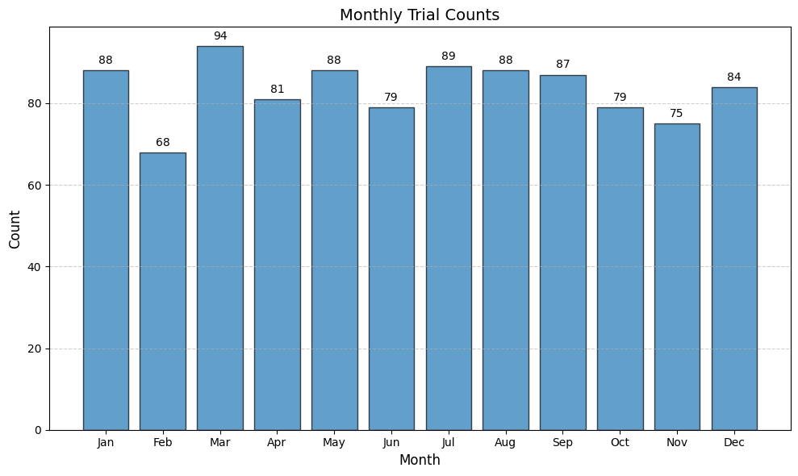

## Q3

What plan `start_date` values occur after the year 2020 for the dataset? Show the breakdown by count of events for each `plan_name`.

```python
query = """
SELECT
    p.plan_name,
    MIN(s.start_date) AS first_start_date,
    MAX(s.start_date) AS last_start_date
FROM
    foodie_fi.subscriptions AS s
        LEFT JOIN foodie_fi.plans AS p ON s.plan_id = p.plan_id
GROUP BY
    p.plan_name;
"""

athena.query(database=database, query=query, ctas_approach=ctas_approach)
```

query = """ SELECT p.plan_name, MIN(s.start_date) AS first_start_date, MAX(s.start_date) AS last_start_date FROM foodie_fi.subscriptions AS s LEFT JOIN foodie_fi.plans AS p ON s.plan_id = p.plan_id GROUP BY p.plan_name; """ athena.query(database=database, query=query, ctas_approach=ctas_approach)

|  | plan_name | first_start_date | last_start_date |
| --- | --- | --- | --- |
| 0 | trial | 2020-01-01 | 2020-12-30 |
| 1 | basic monthly | 2020-01-08 | 2021-01-06 |
| 2 | churn | 2020-01-12 | 2021-04-29 |
| 3 | pro monthly | 2020-01-08 | 2021-04-28 |
| 4 | pro annual | 2020-01-10 | 2021-04-30 |

```python
query = """
SELECT
    p.plan_name,
    COUNT(*) AS events
FROM
    foodie_fi.subscriptions AS s
        LEFT JOIN foodie_fi.plans AS p ON s.plan_id = p.plan_id
WHERE
    EXTRACT(YEAR FROM s.start_date) > 2020
GROUP BY
    p.plan_name
ORDER BY
    events DESC;
"""

athena.query(database=database, query=query, ctas_approach=ctas_approach)
```

query = """ SELECT p.plan_name, COUNT(*) AS events FROM foodie_fi.subscriptions AS s LEFT JOIN foodie_fi.plans AS p ON s.plan_id = p.plan_id WHERE EXTRACT(YEAR FROM s.start_date) > 2020 GROUP BY p.plan_name ORDER BY events DESC; """ athena.query(database=database, query=query, ctas_approach=ctas_approach)

|  | plan_name | events |
| --- | --- | --- |
| 0 | churn | 71 |
| 1 | pro annual | 63 |
| 2 | pro monthly | 60 |
| 3 | basic monthly | 8 |

## Q4

What is the customer count and percentage of customers who have churned rounded to 1 decimal place?

```python
query = """
SELECT
    SUM(CASE WHEN p.plan_name = 'churn' THEN 1.0 ELSE 0.0 END) AS count_churned,
    ROUND((SUM(CASE WHEN p.plan_name = 'churn' THEN 1.0 ELSE 0.0 END) / COUNT(DISTINCT s.customer_id)) * 100.0, 1) AS pct_churned
FROM
    foodie_fi.subscriptions AS s
        LEFT JOIN foodie_fi.plans AS p ON s.plan_id = p.plan_id;
"""

athena.query(database=database, query=query, ctas_approach=ctas_approach)
```

query = """ SELECT SUM(CASE WHEN p.plan_name = 'churn' THEN 1.0 ELSE 0.0 END) AS count_churned, ROUND((SUM(CASE WHEN p.plan_name = 'churn' THEN 1.0 ELSE 0.0 END) / COUNT(DISTINCT s.customer_id)) * 100.0, 1) AS pct_churned FROM foodie_fi.subscriptions AS s LEFT JOIN foodie_fi.plans AS p ON s.plan_id = p.plan_id; """ athena.query(database=database, query=query, ctas_approach=ctas_approach)

|  | count_churned | pct_churned |
| --- | --- | --- |
| 0 | 307.0 | 30.7 |

## Q5

How many customers have churned straight after their initial free trial - what percentage is this rounded to 1 decimal place?

### Gather Each Customer's Plans

We first gather each customer's plan history into an array of comma-separated plans.

In addition, we also create a field called `churn_pattern` that is a two-element array that describes the transition pattern we wish to find.

```python
query = """
SELECT
    s.customer_id,
    ARRAY_AGG(p.plan_name ORDER BY s.start_date ASC) AS plan_progression,
    ARRAY['trial', 'churn'] AS churn_pattern
FROM
    foodie_fi.subscriptions AS s
        LEFT JOIN foodie_fi.plans AS p ON s.plan_id = p.plan_id
GROUP BY
    s.customer_id;
"""

athena.query(database=database, query=query, ctas_approach=ctas_approach)
```

query = """ SELECT s.customer_id, ARRAY_AGG(p.plan_name ORDER BY s.start_date ASC) AS plan_progression, ARRAY['trial', 'churn'] AS churn_pattern FROM foodie_fi.subscriptions AS s LEFT JOIN foodie_fi.plans AS p ON s.plan_id = p.plan_id GROUP BY s.customer_id; """ athena.query(database=database, query=query, ctas_approach=ctas_approach)

|  | customer_id | plan_progression | churn_pattern |
| --- | --- | --- | --- |
| 0 | 9 | [trial, pro annual] | [trial, churn] |
| 1 | 13 | [trial, basic monthly, pro monthly] | [trial, churn] |
| 2 | 15 | [trial, pro monthly, churn] | [trial, churn] |
| 3 | 20 | [trial, basic monthly, pro annual] | [trial, churn] |
| 4 | 26 | [trial, pro monthly] | [trial, churn] |
| ... | ... | ... | ... |
| 995 | 987 | [trial, churn] | [trial, churn] |
| 996 | 989 | [trial, pro monthly, pro annual] | [trial, churn] |
| 997 | 993 | [trial, churn] | [trial, churn] |
| 998 | 995 | [trial, basic monthly, pro monthly] | [trial, churn] |
| 999 | 996 | [trial, basic monthly, churn] | [trial, churn] |

1000 rows × 3 columns

### Check Specific Combination of Plans

Filter for rows where the customers' journeys include the trial plan followed by a churn event.

```python
query = """
WITH customer_journeys AS (
    SELECT
        s.customer_id,
        ARRAY_AGG(p.plan_name ORDER BY s.start_date ASC) AS plan_progression,
        ARRAY['trial', 'churn'] AS churn_pattern
    FROM
        foodie_fi.subscriptions AS s
            LEFT JOIN foodie_fi.plans AS p ON s.plan_id = p.plan_id
    GROUP BY
        s.customer_id
)

SELECT
    COUNT(DISTINCT customer_id) AS churn_after_trial_count,
    (CAST(COUNT(DISTINCT customer_id) AS DOUBLE) / (SELECT COUNT(DISTINCT customer_id) FROM foodie_fi.subscriptions)) * 100.0 AS churn_after_trial_pct
FROM
    customer_journeys
WHERE
    1 = 1
    AND CARDINALITY(plan_progression) = 2
    AND CARDINALITY(ARRAY_INTERSECT(churn_pattern, plan_progression)) = CARDINALITY(churn_pattern);
"""

athena.query(database=database, query=query, ctas_approach=ctas_approach)
```

query = """ WITH customer_journeys AS ( SELECT s.customer_id, ARRAY_AGG(p.plan_name ORDER BY s.start_date ASC) AS plan_progression, ARRAY['trial', 'churn'] AS churn_pattern FROM foodie_fi.subscriptions AS s LEFT JOIN foodie_fi.plans AS p ON s.plan_id = p.plan_id GROUP BY s.customer_id ) SELECT COUNT(DISTINCT customer_id) AS churn_after_trial_count, (CAST(COUNT(DISTINCT customer_id) AS DOUBLE) / (SELECT COUNT(DISTINCT customer_id) FROM foodie_fi.subscriptions)) * 100.0 AS churn_after_trial_pct FROM customer_journeys WHERE 1 = 1 AND CARDINALITY(plan_progression) = 2 AND CARDINALITY(ARRAY_INTERSECT(churn_pattern, plan_progression)) = CARDINALITY(churn_pattern); """ athena.query(database=database, query=query, ctas_approach=ctas_approach)

|  | churn_after_trial_count | churn_after_trial_pct |
| --- | --- | --- |
| 0 | 92 | 9.2 |

### Window Function Approach

First, check the assumption that the first plan for every customer is a trial:

```python
query = """
WITH ranked_data AS (
    SELECT
        s.customer_id,
        p.plan_name,
        RANK() OVER(PARTITION BY s.customer_id ORDER BY s.start_date ASC) AS ranks
    FROM
        foodie_fi.subscriptions AS s
            LEFT JOIN foodie_fi.plans AS p ON s.plan_id = p.plan_id
)
SELECT
    DISTINCT plan_name
FROM
    ranked_data
WHERE
    ranks = 1;
"""

athena.query(database=database, query=query, ctas_approach=ctas_approach)
```

query = """ WITH ranked_data AS ( SELECT s.customer_id, p.plan_name, RANK() OVER(PARTITION BY s.customer_id ORDER BY s.start_date ASC) AS ranks FROM foodie_fi.subscriptions AS s LEFT JOIN foodie_fi.plans AS p ON s.plan_id = p.plan_id ) SELECT DISTINCT plan_name FROM ranked_data WHERE ranks = 1; """ athena.query(database=database, query=query, ctas_approach=ctas_approach)

|  | plan_name |
| --- | --- |
| 0 | trial |

Given that this assumption is valid, we can simply check the second `ranks = 2` plan for each customer to determine if they churned after their trial.

```python
query = """
WITH ranked_data AS (
    SELECT
        s.customer_id,
        p.plan_name,
        RANK() OVER(PARTITION BY s.customer_id ORDER BY s.start_date ASC) AS ranks
    FROM
        foodie_fi.subscriptions AS s
            LEFT JOIN foodie_fi.plans AS p ON s.plan_id = p.plan_id
)
SELECT
    SUM(CASE WHEN plan_name = 'churn' THEN 1.0 ELSE 0.0 END) AS churn_after_trial_count,
    (SUM(CASE WHEN plan_name = 'churn' THEN 1.0 ELSE 0.0 END) / COUNT(DISTINCT customer_id)) * 100.0 AS churn_after_trial_pct
FROM
    ranked_data
WHERE
    1 = 1
    AND ranks = 2;
"""

athena.query(database=database, query=query, ctas_approach=ctas_approach)
```

query = """ WITH ranked_data AS ( SELECT s.customer_id, p.plan_name, RANK() OVER(PARTITION BY s.customer_id ORDER BY s.start_date ASC) AS ranks FROM foodie_fi.subscriptions AS s LEFT JOIN foodie_fi.plans AS p ON s.plan_id = p.plan_id ) SELECT SUM(CASE WHEN plan_name = 'churn' THEN 1.0 ELSE 0.0 END) AS churn_after_trial_count, (SUM(CASE WHEN plan_name = 'churn' THEN 1.0 ELSE 0.0 END) / COUNT(DISTINCT customer_id)) * 100.0 AS churn_after_trial_pct FROM ranked_data WHERE 1 = 1 AND ranks = 2; """ athena.query(database=database, query=query, ctas_approach=ctas_approach)

|  | churn_after_trial_count | churn_after_trial_pct |
| --- | --- | --- |
| 0 | 92.0 | 9.2 |

## Q6

What is the number and percentage of customer plans after their initial free trial?

```python
query = """
WITH ranked_data AS (
    SELECT
        s.customer_id,
        p.plan_name,
        RANK() OVER(PARTITION BY s.customer_id ORDER BY s.start_date ASC) AS ranks
    FROM
        foodie_fi.subscriptions AS s
            LEFT JOIN foodie_fi.plans AS p ON s.plan_id = p.plan_id
)
SELECT
    plan_name,
    COUNT(DISTINCT customer_id) AS customer_count,
    CAST(COUNT(DISTINCT customer_id) AS DOUBLE) / SUM(COUNT(DISTINCT customer_id)) OVER() * 100.0 AS customer_pct
FROM
    ranked_data
WHERE
    1 = 1
    AND ranks = 2
GROUP BY
    plan_name
ORDER BY
    customer_count DESC;
"""

athena.query(database=database, query=query, ctas_approach=ctas_approach)
```

query = """ WITH ranked_data AS ( SELECT s.customer_id, p.plan_name, RANK() OVER(PARTITION BY s.customer_id ORDER BY s.start_date ASC) AS ranks FROM foodie_fi.subscriptions AS s LEFT JOIN foodie_fi.plans AS p ON s.plan_id = p.plan_id ) SELECT plan_name, COUNT(DISTINCT customer_id) AS customer_count, CAST(COUNT(DISTINCT customer_id) AS DOUBLE) / SUM(COUNT(DISTINCT customer_id)) OVER() * 100.0 AS customer_pct FROM ranked_data WHERE 1 = 1 AND ranks = 2 GROUP BY plan_name ORDER BY customer_count DESC; """ athena.query(database=database, query=query, ctas_approach=ctas_approach)

|  | plan_name | customer_count | customer_pct |
| --- | --- | --- | --- |
| 0 | basic monthly | 546 | 54.6 |
| 1 | pro monthly | 325 | 32.5 |
| 2 | churn | 92 | 9.2 |
| 3 | pro annual | 37 | 3.7 |

## Q7

What is the customer count and percentage breakdown of all 5 `plan_name` values at `2020-12-31`?

```python
query = """
WITH ranked_start_dates AS (
    SELECT
        s.customer_id,
        p.plan_name,
        RANK() OVER(PARTITION BY s.customer_id ORDER BY s.start_date DESC) AS ranks
    FROM
        foodie_fi.subscriptions AS s
            LEFT JOIN foodie_fi.plans AS p ON s.plan_id = p.plan_id
    WHERE
        1 = 1
        AND s.start_date <= DATE '2020-12-31'
)
SELECT
    plan_name,
    COUNT(DISTINCT customer_id) AS customer_count,
    CAST(COUNT(DISTINCT customer_id) AS DOUBLE) / SUM(COUNT(DISTINCT customer_id)) OVER() * 100.0 AS customer_pct
FROM
    ranked_start_dates
WHERE
    1 = 1
    AND ranks = 1
GROUP BY
    plan_name
ORDER BY
    customer_count DESC;
"""

athena.query(database=database, query=query, ctas_approach=ctas_approach)
```

query = """ WITH ranked_start_dates AS ( SELECT s.customer_id, p.plan_name, RANK() OVER(PARTITION BY s.customer_id ORDER BY s.start_date DESC) AS ranks FROM foodie_fi.subscriptions AS s LEFT JOIN foodie_fi.plans AS p ON s.plan_id = p.plan_id WHERE 1 = 1 AND s.start_date <= DATE '2020-12-31' ) SELECT plan_name, COUNT(DISTINCT customer_id) AS customer_count, CAST(COUNT(DISTINCT customer_id) AS DOUBLE) / SUM(COUNT(DISTINCT customer_id)) OVER() * 100.0 AS customer_pct FROM ranked_start_dates WHERE 1 = 1 AND ranks = 1 GROUP BY plan_name ORDER BY customer_count DESC; """ athena.query(database=database, query=query, ctas_approach=ctas_approach)

|  | plan_name | customer_count | customer_pct |
| --- | --- | --- | --- |
| 0 | pro monthly | 326 | 32.6 |
| 1 | churn | 236 | 23.6 |
| 2 | basic monthly | 224 | 22.4 |
| 3 | pro annual | 195 | 19.5 |
| 4 | trial | 19 | 1.9 |

## Q8

How many customers have upgraded to an annual plan in 2020?

```python
query = """
SELECT
    COUNT(DISTINCT customer_id) AS upgrades_to_annual
FROM
    foodie_fi.subscriptions AS s
        LEFT JOIN foodie_fi.plans AS p ON s.plan_id = p.plan_id
WHERE
    1 = 1
    AND EXTRACT(YEAR FROM s.start_date) = 2020
    AND p.plan_name = 'pro annual';
"""

athena.query(database=database, query=query, ctas_approach=ctas_approach)
```

query = """ SELECT COUNT(DISTINCT customer_id) AS upgrades_to_annual FROM foodie_fi.subscriptions AS s LEFT JOIN foodie_fi.plans AS p ON s.plan_id = p.plan_id WHERE 1 = 1 AND EXTRACT(YEAR FROM s.start_date) = 2020 AND p.plan_name = 'pro annual'; """ athena.query(database=database, query=query, ctas_approach=ctas_approach)

|  | upgrades_to_annual |
| --- | --- |
| 0 | 195 |

## Q9

How many days on average does it take for a customer to upgrade to an annual plan from the day they join Foodie-Fi?

```python
query = """
WITH customer_journeys AS (
    SELECT
        s.customer_id,
        MIN(s.start_date) AS first_update_date
    FROM
        foodie_fi.subscriptions AS s
            LEFT JOIN foodie_fi.plans AS p ON s.plan_id = p.plan_id
    WHERE
        1 = 1
        AND p.plan_name = 'pro annual'
    GROUP BY
        s.customer_id
),

customer_start_dates AS (
    SELECT
        customer_id,
        MIN(start_date) AS joined_date
    FROM
        foodie_fi.subscriptions
    GROUP BY
        customer_id
)

SELECT
    cj.customer_id,
    cj.first_update_date,
    csd.joined_date,
    DATE_DIFF('DAY', csd.joined_date, cj.first_update_date) AS day_diff
FROM
    customer_journeys AS cj
        LEFT JOIN customer_start_dates AS csd ON cj.customer_id = csd.customer_id;
"""

athena.query(database=database, query=query, ctas_approach=ctas_approach)
```

query = """ WITH customer_journeys AS ( SELECT s.customer_id, MIN(s.start_date) AS first_update_date FROM foodie_fi.subscriptions AS s LEFT JOIN foodie_fi.plans AS p ON s.plan_id = p.plan_id WHERE 1 = 1 AND p.plan_name = 'pro annual' GROUP BY s.customer_id ), customer_start_dates AS ( SELECT customer_id, MIN(start_date) AS joined_date FROM foodie_fi.subscriptions GROUP BY customer_id ) SELECT cj.customer_id, cj.first_update_date, csd.joined_date, DATE_DIFF('DAY', csd.joined_date, cj.first_update_date) AS day_diff FROM customer_journeys AS cj LEFT JOIN customer_start_dates AS csd ON cj.customer_id = csd.customer_id; """ athena.query(database=database, query=query, ctas_approach=ctas_approach)

|  | customer_id | first_update_date | joined_date | day_diff |
| --- | --- | --- | --- | --- |
| 0 | 9 | 2020-12-14 | 2020-12-07 | 7 |
| 1 | 20 | 2020-06-05 | 2020-04-08 | 58 |
| 2 | 28 | 2020-07-07 | 2020-06-30 | 7 |
| 3 | 38 | 2020-11-09 | 2020-10-02 | 38 |
| 4 | 44 | 2020-03-24 | 2020-03-17 | 7 |
| ... | ... | ... | ... | ... |
| 253 | 956 | 2021-01-12 | 2020-02-20 | 327 |
| 254 | 958 | 2021-01-22 | 2020-07-06 | 200 |
| 255 | 961 | 2020-11-21 | 2020-09-12 | 70 |
| 256 | 967 | 2021-04-15 | 2020-08-21 | 237 |
| 257 | 978 | 2020-11-03 | 2020-08-27 | 68 |

258 rows × 4 columns

```python
query = """
WITH customer_journeys AS (
    SELECT
        s.customer_id,
        MIN(s.start_date) AS first_update_date
    FROM
        foodie_fi.subscriptions AS s
            LEFT JOIN foodie_fi.plans AS p ON s.plan_id = p.plan_id
    WHERE
        1 = 1
        AND p.plan_name = 'pro annual'
    GROUP BY
        s.customer_id
),

customer_start_dates AS (
    SELECT
        customer_id,
        MIN(start_date) AS joined_date
    FROM
        foodie_fi.subscriptions
    GROUP BY
        customer_id
)

SELECT
    AVG(DATE_DIFF('DAY', csd.joined_date, cj.first_update_date)) AS avg_days_to_upgrade
FROM
    customer_journeys AS cj
        LEFT JOIN customer_start_dates AS csd ON cj.customer_id = csd.customer_id;
"""

athena.query(database=database, query=query, ctas_approach=ctas_approach)
```

query = """ WITH customer_journeys AS ( SELECT s.customer_id, MIN(s.start_date) AS first_update_date FROM foodie_fi.subscriptions AS s LEFT JOIN foodie_fi.plans AS p ON s.plan_id = p.plan_id WHERE 1 = 1 AND p.plan_name = 'pro annual' GROUP BY s.customer_id ), customer_start_dates AS ( SELECT customer_id, MIN(start_date) AS joined_date FROM foodie_fi.subscriptions GROUP BY customer_id ) SELECT AVG(DATE_DIFF('DAY', csd.joined_date, cj.first_update_date)) AS avg_days_to_upgrade FROM customer_journeys AS cj LEFT JOIN customer_start_dates AS csd ON cj.customer_id = csd.customer_id; """ athena.query(database=database, query=query, ctas_approach=ctas_approach)

|  | avg_days_to_upgrade |
| --- | --- |
| 0 | 104.620155 |

## Q10

Further breakdown the average value computed above into 30 day periods (i.e. 0-30 days, 31-60 days etc).

### Bin Number Calculation

After computing the number of days between the `trial_start_date` and the `upgrade_date`, we can calculate a bin number for each `day_diff` value. This bin number will be used to group the data into 30-day periods.

```python
query = """
WITH customer_journeys AS (
    SELECT
        s.customer_id,
        MIN(s.start_date) AS first_update_date
    FROM
        foodie_fi.subscriptions AS s
            LEFT JOIN foodie_fi.plans AS p ON s.plan_id = p.plan_id
    WHERE
        1 = 1
        AND p.plan_name = 'pro annual'
    GROUP BY
        s.customer_id
),

customer_start_dates AS (
    SELECT
        customer_id,
        MIN(start_date) AS joined_date
    FROM
        foodie_fi.subscriptions
    GROUP BY
        customer_id
)

SELECT
    DATE_DIFF('DAY', csd.joined_date, cj.first_update_date) AS day_diff,
    FLOOR(DATE_DIFF('DAY', csd.joined_date, cj.first_update_date) / 30) AS bin_number
FROM
    customer_journeys AS cj
        LEFT JOIN customer_start_dates AS csd ON cj.customer_id = csd.customer_id;
"""

athena.query(database=database, query=query, ctas_approach=ctas_approach)
```

query = """ WITH customer_journeys AS ( SELECT s.customer_id, MIN(s.start_date) AS first_update_date FROM foodie_fi.subscriptions AS s LEFT JOIN foodie_fi.plans AS p ON s.plan_id = p.plan_id WHERE 1 = 1 AND p.plan_name = 'pro annual' GROUP BY s.customer_id ), customer_start_dates AS ( SELECT customer_id, MIN(start_date) AS joined_date FROM foodie_fi.subscriptions GROUP BY customer_id ) SELECT DATE_DIFF('DAY', csd.joined_date, cj.first_update_date) AS day_diff, FLOOR(DATE_DIFF('DAY', csd.joined_date, cj.first_update_date) / 30) AS bin_number FROM customer_journeys AS cj LEFT JOIN customer_start_dates AS csd ON cj.customer_id = csd.customer_id; """ athena.query(database=database, query=query, ctas_approach=ctas_approach)

|  | day_diff | bin_number |
| --- | --- | --- |
| 0 | 7 | 0 |
| 1 | 158 | 5 |
| 2 | 160 | 5 |
| 3 | 82 | 2 |
| 4 | 7 | 0 |
| ... | ... | ... |
| 253 | 133 | 4 |
| 254 | 78 | 2 |
| 255 | 68 | 2 |
| 256 | 129 | 4 |
| 257 | 36 | 1 |

258 rows × 2 columns

For a bin number $n$, the formulas for computing the start and end of each 30-day bin:

$$ \text{bin\_start} = n \times 30 $$

$$ \text{bin\_end} = (n + 1) \times 30 - 1 $$

```python
query = """
WITH customer_journeys AS (
    SELECT
        s.customer_id,
        MIN(s.start_date) AS first_update_date
    FROM
        foodie_fi.subscriptions AS s
            LEFT JOIN foodie_fi.plans AS p ON s.plan_id = p.plan_id
    WHERE
        1 = 1
        AND p.plan_name = 'pro annual'
    GROUP BY
        s.customer_id
),

customer_start_dates AS (
    SELECT
        customer_id,
        MIN(start_date) AS joined_date
    FROM
        foodie_fi.subscriptions
    GROUP BY
        customer_id
),

diff_bins AS (
    SELECT
        DATE_DIFF('DAY', csd.joined_date, cj.first_update_date) AS day_diff,
        FLOOR(DATE_DIFF('DAY', csd.joined_date, cj.first_update_date) / 30) AS bin_number
    FROM
        customer_journeys AS cj
            LEFT JOIN customer_start_dates AS csd ON cj.customer_id = csd.customer_id
)

SELECT
    CONCAT(CAST(bin_number * 30 AS VARCHAR), ' - ', CAST((bin_number + 1) * 30 - 1 AS VARCHAR), ' days') AS breakdown_period,
    COUNT(*) as count
FROM
    diff_bins
GROUP BY
    bin_number
ORDER BY
    bin_number;
"""

athena.query(database=database, query=query, ctas_approach=ctas_approach)
```

query = """ WITH customer_journeys AS ( SELECT s.customer_id, MIN(s.start_date) AS first_update_date FROM foodie_fi.subscriptions AS s LEFT JOIN foodie_fi.plans AS p ON s.plan_id = p.plan_id WHERE 1 = 1 AND p.plan_name = 'pro annual' GROUP BY s.customer_id ), customer_start_dates AS ( SELECT customer_id, MIN(start_date) AS joined_date FROM foodie_fi.subscriptions GROUP BY customer_id ), diff_bins AS ( SELECT DATE_DIFF('DAY', csd.joined_date, cj.first_update_date) AS day_diff, FLOOR(DATE_DIFF('DAY', csd.joined_date, cj.first_update_date) / 30) AS bin_number FROM customer_journeys AS cj LEFT JOIN customer_start_dates AS csd ON cj.customer_id = csd.customer_id ) SELECT CONCAT(CAST(bin_number * 30 AS VARCHAR), ' - ', CAST((bin_number + 1) * 30 - 1 AS VARCHAR), ' days') AS breakdown_period, COUNT(*) as count FROM diff_bins GROUP BY bin_number ORDER BY bin_number; """ athena.query(database=database, query=query, ctas_approach=ctas_approach)

|  | breakdown_period | count |
| --- | --- | --- |
| 0 | 0 - 29 days | 48 |
| 1 | 30 - 59 days | 25 |
| 2 | 60 - 89 days | 33 |
| 3 | 90 - 119 days | 35 |
| 4 | 120 - 149 days | 43 |
| 5 | 150 - 179 days | 35 |
| 6 | 180 - 209 days | 27 |
| 7 | 210 - 239 days | 4 |
| 8 | 240 - 269 days | 5 |
| 9 | 270 - 299 days | 1 |
| 10 | 300 - 329 days | 1 |
| 11 | 330 - 359 days | 1 |

## Q11

How many customers downgraded from a pro monthly to a basic monthly plan in 2020?

### Downgrade Counts

```python
query = """
SELECT
    s.customer_id,
    s.start_date,
    LAG(s.start_date, 1) OVER(PARTITION BY customer_id ORDER BY s.start_date ASC) AS previous_start_date,
    p.plan_name,
    LAG(p.plan_name, 1) OVER(PARTITION BY customer_id ORDER BY s.start_date ASC) AS previous_plan_name
FROM
    foodie_fi.subscriptions AS s
        LEFT JOIN foodie_fi.plans AS p ON s.plan_id = p.plan_id
ORDER BY
    s.customer_id,
    s.start_date;
"""

athena.query(database=database, query=query, ctas_approach=ctas_approach)
```

query = """ SELECT s.customer_id, s.start_date, LAG(s.start_date, 1) OVER(PARTITION BY customer_id ORDER BY s.start_date ASC) AS previous_start_date, p.plan_name, LAG(p.plan_name, 1) OVER(PARTITION BY customer_id ORDER BY s.start_date ASC) AS previous_plan_name FROM foodie_fi.subscriptions AS s LEFT JOIN foodie_fi.plans AS p ON s.plan_id = p.plan_id ORDER BY s.customer_id, s.start_date; """ athena.query(database=database, query=query, ctas_approach=ctas_approach)

|  | customer_id | start_date | previous_start_date | plan_name | previous_plan_name |
| --- | --- | --- | --- | --- | --- |
| 0 | 1 | 2020-08-01 | NaT | trial | <NA> |
| 1 | 1 | 2020-08-08 | 2020-08-01 | basic monthly | trial |
| 2 | 2 | 2020-09-20 | NaT | trial | <NA> |
| 3 | 2 | 2020-09-27 | 2020-09-20 | pro annual | trial |
| 4 | 3 | 2020-01-13 | NaT | trial | <NA> |
| ... | ... | ... | ... | ... | ... |
| 2645 | 999 | 2020-10-30 | 2020-10-23 | pro monthly | trial |
| 2646 | 999 | 2020-12-01 | 2020-10-30 | churn | pro monthly |
| 2647 | 1000 | 2020-03-19 | NaT | trial | <NA> |
| 2648 | 1000 | 2020-03-26 | 2020-03-19 | pro monthly | trial |
| 2649 | 1000 | 2020-06-04 | 2020-03-26 | churn | pro monthly |

2650 rows × 5 columns

```python
query = """
WITH ranked_data AS (
    SELECT
        s.customer_id,
        s.start_date,
        p.plan_name,
        LAG(p.plan_name, 1) OVER(PARTITION BY customer_id ORDER BY s.start_date ASC) AS previous_plan_name
    FROM
        foodie_fi.subscriptions AS s
            LEFT JOIN foodie_fi.plans AS p ON s.plan_id = p.plan_id
)
SELECT
    COUNT(DISTINCT customer_id) AS downgrades_count
FROM
    ranked_data
WHERE
    1 = 1
    AND plan_name = 'basic monthly'
    AND previous_plan_name = 'pro monthly'
    AND EXTRACT(YEAR FROM start_date) = 2020;
"""

athena.query(database=database, query=query, ctas_approach=ctas_approach)
```

query = """ WITH ranked_data AS ( SELECT s.customer_id, s.start_date, p.plan_name, LAG(p.plan_name, 1) OVER(PARTITION BY customer_id ORDER BY s.start_date ASC) AS previous_plan_name FROM foodie_fi.subscriptions AS s LEFT JOIN foodie_fi.plans AS p ON s.plan_id = p.plan_id ) SELECT COUNT(DISTINCT customer_id) AS downgrades_count FROM ranked_data WHERE 1 = 1 AND plan_name = 'basic monthly' AND previous_plan_name = 'pro monthly' AND EXTRACT(YEAR FROM start_date) = 2020; """ athena.query(database=database, query=query, ctas_approach=ctas_approach)

|  | downgrades_count |
| --- | --- |
| 0 | 0 |

### Upgrade Counts

```python
query = """
SELECT
    s.customer_id,
    s.start_date,
    LEAD(s.start_date, 1) OVER(PARTITION BY customer_id ORDER BY s.start_date ASC) AS next_start_date,
    p.plan_name,
    LEAD(p.plan_name, 1) OVER(PARTITION BY customer_id ORDER BY s.start_date ASC) AS next_plan_name
FROM
    foodie_fi.subscriptions AS s
        LEFT JOIN foodie_fi.plans AS p ON s.plan_id = p.plan_id
ORDER BY
    s.customer_id,
    s.start_date;
"""

athena.query(database=database, query=query, ctas_approach=ctas_approach)
```

query = """ SELECT s.customer_id, s.start_date, LEAD(s.start_date, 1) OVER(PARTITION BY customer_id ORDER BY s.start_date ASC) AS next_start_date, p.plan_name, LEAD(p.plan_name, 1) OVER(PARTITION BY customer_id ORDER BY s.start_date ASC) AS next_plan_name FROM foodie_fi.subscriptions AS s LEFT JOIN foodie_fi.plans AS p ON s.plan_id = p.plan_id ORDER BY s.customer_id, s.start_date; """ athena.query(database=database, query=query, ctas_approach=ctas_approach)

|  | customer_id | start_date | next_start_date | plan_name | next_plan_name |
| --- | --- | --- | --- | --- | --- |
| 0 | 1 | 2020-08-01 | 2020-08-08 | trial | basic monthly |
| 1 | 1 | 2020-08-08 | NaT | basic monthly | <NA> |
| 2 | 2 | 2020-09-20 | 2020-09-27 | trial | pro annual |
| 3 | 2 | 2020-09-27 | NaT | pro annual | <NA> |
| 4 | 3 | 2020-01-13 | 2020-01-20 | trial | basic monthly |
| ... | ... | ... | ... | ... | ... |
| 2645 | 999 | 2020-10-30 | 2020-12-01 | pro monthly | churn |
| 2646 | 999 | 2020-12-01 | NaT | churn | <NA> |
| 2647 | 1000 | 2020-03-19 | 2020-03-26 | trial | pro monthly |
| 2648 | 1000 | 2020-03-26 | 2020-06-04 | pro monthly | churn |
| 2649 | 1000 | 2020-06-04 | NaT | churn | <NA> |

2650 rows × 5 columns

```python
query = """
WITH ranked_data AS (
    SELECT
        s.customer_id,
        s.start_date,
        LEAD(s.start_date, 1) OVER(PARTITION BY customer_id ORDER BY s.start_date ASC) AS next_start_date,
        p.plan_name,
        LEAD(p.plan_name, 1) OVER(PARTITION BY customer_id ORDER BY s.start_date ASC) AS next_plan_name
    FROM
        foodie_fi.subscriptions AS s
            LEFT JOIN foodie_fi.plans AS p ON s.plan_id = p.plan_id
)
SELECT
    COUNT(DISTINCT customer_id) AS upgrades_count
FROM
    ranked_data
WHERE
    1 = 1
    AND plan_name = 'basic monthly'
    AND next_plan_name = 'pro monthly'
    AND EXTRACT(YEAR FROM next_start_date) = 2020;
"""

athena.query(database=database, query=query, ctas_approach=ctas_approach)
```

query = """ WITH ranked_data AS ( SELECT s.customer_id, s.start_date, LEAD(s.start_date, 1) OVER(PARTITION BY customer_id ORDER BY s.start_date ASC) AS next_start_date, p.plan_name, LEAD(p.plan_name, 1) OVER(PARTITION BY customer_id ORDER BY s.start_date ASC) AS next_plan_name FROM foodie_fi.subscriptions AS s LEFT JOIN foodie_fi.plans AS p ON s.plan_id = p.plan_id ) SELECT COUNT(DISTINCT customer_id) AS upgrades_count FROM ranked_data WHERE 1 = 1 AND plan_name = 'basic monthly' AND next_plan_name = 'pro monthly' AND EXTRACT(YEAR FROM next_start_date) = 2020; """ athena.query(database=database, query=query, ctas_approach=ctas_approach)

|  | upgrades_count |
| --- | --- |
| 0 | 163 |

## Transition Matrix Analysis

### Counts

```python
query = """
WITH transitions AS (
    SELECT
        s.customer_id,
        s.start_date,
        LEAD(s.start_date, 1) OVER(PARTITION BY customer_id ORDER BY s.start_date ASC) AS next_start_date,
        p.plan_name,
        LEAD(p.plan_name, 1) OVER(PARTITION BY customer_id ORDER BY s.start_date ASC) AS next_plan_name
    FROM
        foodie_fi.subscriptions AS s
            LEFT JOIN foodie_fi.plans AS p ON s.plan_id = p.plan_id
),

transition_counts AS (
    SELECT
        plan_name,
        next_plan_name,
        COUNT(DISTINCT customer_id) AS transition_count
    FROM
        transitions
    WHERE
        next_plan_name IS NOT NULL
    GROUP BY
        plan_name, next_plan_name
)

SELECT
    plan_name,
    COALESCE(SUM(CASE WHEN next_plan_name = 'trial' THEN transition_count END), 0) AS trial,
    COALESCE(SUM(CASE WHEN next_plan_name = 'basic monthly' THEN transition_count END), 0) AS basic_monthly,
    COALESCE(SUM(CASE WHEN next_plan_name = 'pro monthly' THEN transition_count END), 0) AS pro_monthly,
    COALESCE(SUM(CASE WHEN next_plan_name = 'pro annual' THEN transition_count END), 0) AS pro_annual,
    COALESCE(SUM(CASE WHEN next_plan_name = 'churn' THEN transition_count END), 0) AS churn
FROM
    transition_counts
GROUP BY
    plan_name
ORDER BY
    plan_name;
"""

transition_matrix_counts = (
    athena.query(database=database, query=query, ctas_approach=ctas_approach)
    .set_index("plan_name")
    .astype(int)
)
transition_matrix_counts
```

query = """ WITH transitions AS ( SELECT s.customer_id, s.start_date, LEAD(s.start_date, 1) OVER(PARTITION BY customer_id ORDER BY s.start_date ASC) AS next_start_date, p.plan_name, LEAD(p.plan_name, 1) OVER(PARTITION BY customer_id ORDER BY s.start_date ASC) AS next_plan_name FROM foodie_fi.subscriptions AS s LEFT JOIN foodie_fi.plans AS p ON s.plan_id = p.plan_id ), transition_counts AS ( SELECT plan_name, next_plan_name, COUNT(DISTINCT customer_id) AS transition_count FROM transitions WHERE next_plan_name IS NOT NULL GROUP BY plan_name, next_plan_name ) SELECT plan_name, COALESCE(SUM(CASE WHEN next_plan_name = 'trial' THEN transition_count END), 0) AS trial, COALESCE(SUM(CASE WHEN next_plan_name = 'basic monthly' THEN transition_count END), 0) AS basic_monthly, COALESCE(SUM(CASE WHEN next_plan_name = 'pro monthly' THEN transition_count END), 0) AS pro_monthly, COALESCE(SUM(CASE WHEN next_plan_name = 'pro annual' THEN transition_count END), 0) AS pro_annual, COALESCE(SUM(CASE WHEN next_plan_name = 'churn' THEN transition_count END), 0) AS churn FROM transition_counts GROUP BY plan_name ORDER BY plan_name; """ transition_matrix_counts = ( athena.query(database=database, query=query, ctas_approach=ctas_approach) .set_index("plan_name") .astype(int) ) transition_matrix_counts

| plan_name | trial | basic_monthly | pro_monthly | pro_annual | churn |
| --- | --- | --- | --- | --- | --- |
| basic monthly | 0 | 0 | 214 | 110 | 97 |
| pro annual | 0 | 0 | 0 | 0 | 6 |
| pro monthly | 0 | 0 | 0 | 111 | 112 |
| trial | 0 | 546 | 325 | 37 | 92 |

```python
plt.figure(figsize=(10, 6))
sns.heatmap(transition_matrix_counts, annot=True, fmt="d", cmap="Blues", cbar=True)
plt.title("Transition Heatmap (Counts)")
plt.xlabel("Next Plan")
plt.ylabel("Current Plan")
plt.show();
```

plt.figure(figsize=(10, 6)) sns.heatmap(transition_matrix_counts, annot=True, fmt="d", cmap="Blues", cbar=True) plt.title("Transition Heatmap (Counts)") plt.xlabel("Next Plan") plt.ylabel("Current Plan") plt.show();

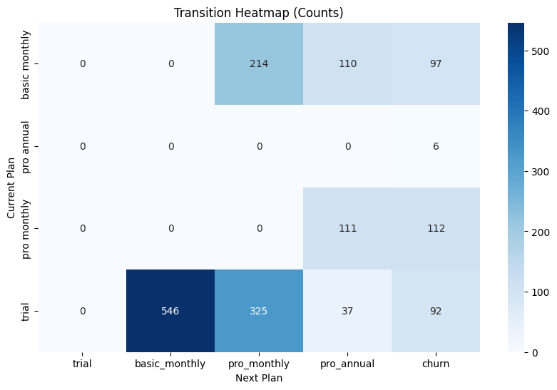

### Probabilities

```python
query = """
WITH transitions AS (
    SELECT
        s.customer_id,
        s.start_date,
        LEAD(s.start_date, 1) OVER(PARTITION BY s.customer_id ORDER BY s.start_date ASC) AS next_start_date,
        p.plan_name,
        LEAD(p.plan_name, 1) OVER(PARTITION BY s.customer_id ORDER BY s.start_date ASC) AS next_plan_name
    FROM
        foodie_fi.subscriptions AS s
    LEFT JOIN
        foodie_fi.plans AS p
    ON
        s.plan_id = p.plan_id
),

transition_counts AS (
    SELECT
        plan_name,
        next_plan_name,
        COUNT(DISTINCT customer_id) AS transition_count
    FROM
        transitions
    WHERE
        next_plan_name IS NOT NULL
    GROUP BY
        plan_name, next_plan_name
),

row_totals AS (
    SELECT
        plan_name,
        SUM(transition_count) AS total_transitions
    FROM
        transition_counts
    GROUP BY
        plan_name
)

SELECT
    tc.plan_name,
    ROUND(COALESCE(SUM(CASE WHEN tc.next_plan_name = 'trial' THEN CAST(tc.transition_count AS DOUBLE) / rt.total_transitions END), 0), 4) AS trial,
    ROUND(COALESCE(SUM(CASE WHEN tc.next_plan_name = 'basic monthly' THEN CAST(tc.transition_count AS DOUBLE) / rt.total_transitions END), 0), 4) AS basic_monthly,
    ROUND(COALESCE(SUM(CASE WHEN tc.next_plan_name = 'pro monthly' THEN CAST(tc.transition_count AS DOUBLE) / rt.total_transitions END), 0), 4) AS pro_monthly,
    ROUND(COALESCE(SUM(CASE WHEN tc.next_plan_name = 'pro annual' THEN CAST(tc.transition_count AS DOUBLE) / rt.total_transitions END), 0), 4) AS pro_annual,
    ROUND(COALESCE(SUM(CASE WHEN tc.next_plan_name = 'churn' THEN CAST(tc.transition_count AS DOUBLE) / rt.total_transitions END), 0), 4) AS churn
FROM
    transition_counts AS tc
JOIN
    row_totals AS rt
ON
    tc.plan_name = rt.plan_name
GROUP BY
    tc.plan_name
ORDER BY
    tc.plan_name;
"""

transition_matrix_probs = (
    athena.query(database=database, query=query, ctas_approach=ctas_approach)
    .set_index("plan_name")
    .astype(float)
)
transition_matrix_probs
```

query = """ WITH transitions AS ( SELECT s.customer_id, s.start_date, LEAD(s.start_date, 1) OVER(PARTITION BY s.customer_id ORDER BY s.start_date ASC) AS next_start_date, p.plan_name, LEAD(p.plan_name, 1) OVER(PARTITION BY s.customer_id ORDER BY s.start_date ASC) AS next_plan_name FROM foodie_fi.subscriptions AS s LEFT JOIN foodie_fi.plans AS p ON s.plan_id = p.plan_id ), transition_counts AS ( SELECT plan_name, next_plan_name, COUNT(DISTINCT customer_id) AS transition_count FROM transitions WHERE next_plan_name IS NOT NULL GROUP BY plan_name, next_plan_name ), row_totals AS ( SELECT plan_name, SUM(transition_count) AS total_transitions FROM transition_counts GROUP BY plan_name ) SELECT tc.plan_name, ROUND(COALESCE(SUM(CASE WHEN tc.next_plan_name = 'trial' THEN CAST(tc.transition_count AS DOUBLE) / rt.total_transitions END), 0), 4) AS trial, ROUND(COALESCE(SUM(CASE WHEN tc.next_plan_name = 'basic monthly' THEN CAST(tc.transition_count AS DOUBLE) / rt.total_transitions END), 0), 4) AS basic_monthly, ROUND(COALESCE(SUM(CASE WHEN tc.next_plan_name = 'pro monthly' THEN CAST(tc.transition_count AS DOUBLE) / rt.total_transitions END), 0), 4) AS pro_monthly, ROUND(COALESCE(SUM(CASE WHEN tc.next_plan_name = 'pro annual' THEN CAST(tc.transition_count AS DOUBLE) / rt.total_transitions END), 0), 4) AS pro_annual, ROUND(COALESCE(SUM(CASE WHEN tc.next_plan_name = 'churn' THEN CAST(tc.transition_count AS DOUBLE) / rt.total_transitions END), 0), 4) AS churn FROM transition_counts AS tc JOIN row_totals AS rt ON tc.plan_name = rt.plan_name GROUP BY tc.plan_name ORDER BY tc.plan_name; """ transition_matrix_probs = ( athena.query(database=database, query=query, ctas_approach=ctas_approach) .set_index("plan_name") .astype(float) ) transition_matrix_probs

| plan_name | trial | basic_monthly | pro_monthly | pro_annual | churn |
| --- | --- | --- | --- | --- | --- |
| basic monthly | 0.0 | 0.000 | 0.5083 | 0.2613 | 0.2304 |
| pro annual | 0.0 | 0.000 | 0.0000 | 0.0000 | 1.0000 |
| pro monthly | 0.0 | 0.000 | 0.0000 | 0.4978 | 0.5022 |
| trial | 0.0 | 0.546 | 0.3250 | 0.0370 | 0.0920 |

```python
plt.figure(figsize=(10, 6))
sns.heatmap(transition_matrix_probs, annot=True, fmt=".2f", cmap="Blues", cbar=True)
plt.title("Transition Heatmap (Probabilities)")
plt.xlabel("Next Plan")
plt.ylabel("Current Plan")
plt.show();
```

plt.figure(figsize=(10, 6)) sns.heatmap(transition_matrix_probs, annot=True, fmt=".2f", cmap="Blues", cbar=True) plt.title("Transition Heatmap (Probabilities)") plt.xlabel("Next Plan") plt.ylabel("Current Plan") plt.show();

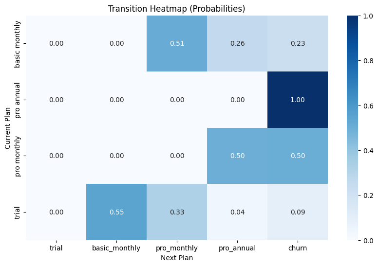

## Payment Table

The Foodie-Fi team wants a new `payments` table for the year 2020. This table should include the amounts paid by each customer from the subscriptions table, following these rules:

1. **Monthly Payment Schedule:** Payments for monthly plans occur on the same day of the month as the original subscription's `start_date`.
2. **Upgrades to Higher Plans:**
   - If a customer upgrades from a basic plan to a monthly or pro plan, the amount already paid for the current month is deducted from the upgrade cost, and the new plan starts immediately.
   - If a customer upgrades from a pro monthly plan to a pro annual plan, the payment for the annual plan is made at the end of the current monthly billing cycle, and the annual plan begins at that time.
3. **Churned Customers:** Once a customer churns, they no longer make any payments.

### Approach

We need to partition the entire sample space into 5 cases that are disjoint and exhaustive:

- Case 1: Customers with monthly plans who haven't churned as of `2020-12-31`. Their payments are calculated up to the end of the year.
- Case 2: Customers who churned in 2020, capturing payments from their start date to one day before the churn date.
- Case 3: Customers upgrading from basic to pro monthly or annual plans, with payments calculated for the duration of their basic plan.
- Case 4: Pro monthly customers who upgrade to pro annual plans. Payments are captured for the monthly plan before the upgrade.
- Case 5: Customers on pro annual plans, with a single payment captured for their annual subscription.

These cases were identified through exploratory data analysis (EDA) and ensure a perfect partitioning of the sample space. It is not necessary to account for every theoretical permutation of transitions between plans but rather to focus solely on transitions that have occurred or are plausible based on the observed data.

### Lead Plans CTE

The `lead_plans` CTE is the base CTE that identifies each customer's current plan and the next plan (if any) during 2020:

- **Columns:**
  - `customer_id`, `plan_id`, and `start_date`: The customer's current plan and its start date.
  - `lead_plan_id`: The next plan for the customer (using `LEAD(plan_id)`).
  - `lead_start_date`: The start date of the next plan (`LEAD(start_date)`).
- **Logic:**
  - **Window Function:** Groups by `customer_id` and orders plans by `start_date` in ascending order to find the next plan and its start date.
  - **Filters:** Filters out plan_id = 0 (trial) and focuses on active subscriptions in 2020.
  - **Ordering:** Ensures output is sorted by customer and subscription timeline.

Purpose: Tracks plan transitions for each customer in 2020.

```python
query = """
SELECT
    customer_id,
    plan_id,
    start_date,

    LEAD (plan_id) OVER (
        PARTITION BY
            customer_id
        ORDER BY
            start_date ASC
    ) AS lead_plan_id,

    LEAD (start_date) OVER (
        PARTITION BY
            customer_id
        ORDER BY
            start_date ASC
    ) AS lead_start_date

FROM
    foodie_fi.subscriptions
WHERE
    year (start_date) = 2020
    AND plan_id != 0;
"""

athena.query(database=database, query=query, ctas_approach=ctas_approach)
```

query = """ SELECT customer_id, plan_id, start_date, LEAD (plan_id) OVER ( PARTITION BY customer_id ORDER BY start_date ASC ) AS lead_plan_id, LEAD (start_date) OVER ( PARTITION BY customer_id ORDER BY start_date ASC ) AS lead_start_date FROM foodie_fi.subscriptions WHERE year (start_date) = 2020 AND plan_id != 0; """ athena.query(database=database, query=query, ctas_approach=ctas_approach)

|  | customer_id | plan_id | start_date | lead_plan_id | lead_start_date |
| --- | --- | --- | --- | --- | --- |
| 0 | 9 | 3 | 2020-12-14 | <NA> | NaT |
| 1 | 13 | 1 | 2020-12-22 | <NA> | NaT |
| 2 | 15 | 2 | 2020-03-24 | 4 | 2020-04-29 |
| 3 | 15 | 4 | 2020-04-29 | <NA> | NaT |
| 4 | 20 | 1 | 2020-04-15 | 3 | 2020-06-05 |
| ... | ... | ... | ... | ... | ... |
| 1443 | 997 | 1 | 2020-08-03 | 2 | 2020-08-26 |
| 1444 | 997 | 2 | 2020-08-26 | 4 | 2020-11-14 |
| 1445 | 997 | 4 | 2020-11-14 | <NA> | NaT |
| 1446 | 999 | 2 | 2020-10-30 | 4 | 2020-12-01 |
| 1447 | 999 | 4 | 2020-12-01 | <NA> | NaT |

1448 rows × 5 columns

### Case 1: Non-Churn Monthly Customers

**Query:**

The first query selects customers on monthly plans who **did not churn** by `2020-12-31`.

- **Logic:**
  - Use `lead_plans` to find subscriptions with no next plan (`lead_plan_id IS NULL`).
  - Exclude churn (`plan_id = 4`) and annual plans (`plan_id = 3`).
  - Calculate `month_diff`, the number of months from the subscription `start_date` to `2020-12-31`. This is so that we can generate monthly payment dates for each customer for each payment month in 2020.

**Output:**

Each row represents a qualifying customer with their monthly plan, start date, and the total months they are active in 2020.

```python
query = """
WITH lead_plans AS (
    SELECT
        customer_id,
        plan_id,
        start_date,
        LEAD (plan_id) OVER (
            PARTITION BY
                customer_id
            ORDER BY
                start_date
        ) AS lead_plan_id,
        LEAD (start_date) OVER (
            PARTITION BY
                customer_id
            ORDER BY
                start_date
        ) AS lead_start_date
    FROM
        foodie_fi.subscriptions
    WHERE
        year (start_date) = 2020
        AND plan_id != 0
)

SELECT
    customer_id,
    plan_id,
    start_date,
    DATE_DIFF('MONTH', start_date, DATE '2020-12-31') AS month_diff
FROM
    lead_plans
WHERE
    lead_plan_id IS NULL
    AND plan_id NOT IN (3, 4) -- Exclude churn and annual plans;
"""

athena.query(database=database, query=query, ctas_approach=ctas_approach)
```

query = """ WITH lead_plans AS ( SELECT customer_id, plan_id, start_date, LEAD (plan_id) OVER ( PARTITION BY customer_id ORDER BY start_date ) AS lead_plan_id, LEAD (start_date) OVER ( PARTITION BY customer_id ORDER BY start_date ) AS lead_start_date FROM foodie_fi.subscriptions WHERE year (start_date) = 2020 AND plan_id != 0 ) SELECT customer_id, plan_id, start_date, DATE_DIFF('MONTH', start_date, DATE '2020-12-31') AS month_diff FROM lead_plans WHERE lead_plan_id IS NULL AND plan_id NOT IN (3, 4) -- Exclude churn and annual plans; """ athena.query(database=database, query=query, ctas_approach=ctas_approach)

|  | customer_id | plan_id | start_date | month_diff |
| --- | --- | --- | --- | --- |
| 0 | 13 | 1 | 2020-12-22 | 0 |
| 1 | 26 | 2 | 2020-12-15 | 0 |
| 2 | 34 | 1 | 2020-12-27 | 0 |
| 3 | 41 | 2 | 2020-05-23 | 7 |
| 4 | 54 | 2 | 2020-05-30 | 7 |
| ... | ... | ... | ... | ... |
| 545 | 963 | 2 | 2020-01-11 | 11 |
| 546 | 965 | 1 | 2020-06-26 | 6 |
| 547 | 980 | 2 | 2020-06-19 | 6 |
| 548 | 989 | 2 | 2020-09-10 | 3 |
| 549 | 995 | 2 | 2020-12-06 | 0 |

550 rows × 4 columns

**Query:**

The second query calculates **monthly payment dates** for the customers identified in Step 1.

- **Logic:**
  - Use `SEQUENCE(0, month_diff)` to generate a series of numbers (0 to `month_diff`).
  - Use `DATE_ADD('MONTH', seq, start_date)` to compute each monthly payment date.
  - `CROSS JOIN UNNEST` applies the sequence to each customer, creating a row for each payment.

**Output:**

Each row represents a payment for a customer, with `customer_id`, `plan_id`, and `payment_date`.

```python
query = """
WITH lead_plans AS (
    SELECT
        customer_id,
        plan_id,
        start_date,
        LEAD (plan_id) OVER (
            PARTITION BY
                customer_id
            ORDER BY
                start_date
        ) AS lead_plan_id,
        LEAD (start_date) OVER (
            PARTITION BY
                customer_id
            ORDER BY
                start_date
        ) AS lead_start_date
    FROM
        foodie_fi.subscriptions
    WHERE
        year (start_date) = 2020
        AND plan_id != 0
),

-- Case 1: Non-churn monthly customers

case_1 AS (
    SELECT
        customer_id,
        plan_id,
        start_date,
        DATE_DIFF('MONTH', start_date, DATE '2020-12-31') AS month_diff
    FROM
        lead_plans
    WHERE
        lead_plan_id IS NULL
        AND plan_id NOT IN (3, 4) -- Exclude churn and annual plans
)

-- Generate payments for case 1 customers

SELECT
    customer_id,
    plan_id,
    DATE_ADD('MONTH', seq, start_date) AS payment_date
FROM
    case_1
    CROSS JOIN UNNEST (SEQUENCE (0, month_diff)) AS t (seq);
"""

athena.query(database=database, query=query, ctas_approach=ctas_approach)
```

query = """ WITH lead_plans AS ( SELECT customer_id, plan_id, start_date, LEAD (plan_id) OVER ( PARTITION BY customer_id ORDER BY start_date ) AS lead_plan_id, LEAD (start_date) OVER ( PARTITION BY customer_id ORDER BY start_date ) AS lead_start_date FROM foodie_fi.subscriptions WHERE year (start_date) = 2020 AND plan_id != 0 ), -- Case 1: Non-churn monthly customers case_1 AS ( SELECT customer_id, plan_id, start_date, DATE_DIFF('MONTH', start_date, DATE '2020-12-31') AS month_diff FROM lead_plans WHERE lead_plan_id IS NULL AND plan_id NOT IN (3, 4) -- Exclude churn and annual plans ) -- Generate payments for case 1 customers SELECT customer_id, plan_id, DATE_ADD('MONTH', seq, start_date) AS payment_date FROM case_1 CROSS JOIN UNNEST (SEQUENCE (0, month_diff)) AS t (seq); """ athena.query(database=database, query=query, ctas_approach=ctas_approach)

|  | customer_id | plan_id | payment_date |
| --- | --- | --- | --- |
| 0 | 1 | 1 | 2020-08-08 |
| 1 | 1 | 1 | 2020-09-08 |
| 2 | 1 | 1 | 2020-10-08 |
| 3 | 1 | 1 | 2020-11-08 |
| 4 | 1 | 1 | 2020-12-08 |
| ... | ... | ... | ... |
| 2768 | 994 | 2 | 2020-08-27 |
| 2769 | 994 | 2 | 2020-09-27 |
| 2770 | 994 | 2 | 2020-10-27 |
| 2771 | 994 | 2 | 2020-11-27 |
| 2772 | 994 | 2 | 2020-12-27 |

2773 rows × 3 columns

### Case 2: Churn Customers

**Query:**

The first query identifies customers who **churned** in 2020.

- **Logic:**
  - Use `lead_plans` to find customers whose next plan (`lead_plan_id`) is `4` (churn).
  - Calculate `month_diff` as the number of months between the `start_date` and the day before their `lead_start_date` (churn date).
    1. **Purpose of `DATE_DIFF('MONTH', ...)`:**
       - This calculates the number of full months between the `start_date` (when the current plan began) and the date just before the `lead_start_date` (when the next plan starts).
       - Using `DATE_ADD('DAY', -1, lead_start_date)` ensures that the upgrade day itself is excluded, so the calculation only covers the period the customer was on the basic plan.
    2. **Why Subtract 1 Day (`DATE_ADD('DAY', -1, lead_start_date)`)?**
       - By default, `DATE_DIFF` counts the difference inclusive of both start and end dates if they fall on the same calendar month.
       - Subtracting 1 day ensures that if the upgrade happens at the beginning of a new month, only the full months spent on the current plan are included.
    - **Scenario:** A customer starts a basic plan on `2020-03-15` and churns on `2020-06-01`.
      - Without subtracting a day: `DATE_DIFF('MONTH', '2020-03-15', '2020-06-01')` = 3 (March → June).
      - With subtraction: `DATE_DIFF('MONTH', '2020-03-15', '2020-05-31')` = 2 (March → May).

      This ensures accurate billing by capturing only the months the customer was on the current plan.

**Output:**

Each row represents a customer who churned, with their plan, subscription start date, and the total months of payments before churning.

```python
query = """
WITH lead_plans AS (
    SELECT
        customer_id,
        plan_id,
        start_date,
        LEAD (plan_id) OVER (
            PARTITION BY
                customer_id
            ORDER BY
                start_date
        ) AS lead_plan_id,
        LEAD (start_date) OVER (
            PARTITION BY
                customer_id
            ORDER BY
                start_date
        ) AS lead_start_date
    FROM
        foodie_fi.subscriptions
    WHERE
        year (start_date) = 2020
        AND plan_id != 0
)

SELECT
    customer_id,
    plan_id,
    start_date,
    DATE_DIFF(
        'MONTH',
        start_date,
        DATE_ADD('DAY', -1, lead_start_date)
    ) AS month_diff
FROM
    lead_plans
WHERE
    lead_plan_id = 4;
"""

athena.query(database=database, query=query, ctas_approach=ctas_approach)
```

query = """ WITH lead_plans AS ( SELECT customer_id, plan_id, start_date, LEAD (plan_id) OVER ( PARTITION BY customer_id ORDER BY start_date ) AS lead_plan_id, LEAD (start_date) OVER ( PARTITION BY customer_id ORDER BY start_date ) AS lead_start_date FROM foodie_fi.subscriptions WHERE year (start_date) = 2020 AND plan_id != 0 ) SELECT customer_id, plan_id, start_date, DATE_DIFF( 'MONTH', start_date, DATE_ADD('DAY', -1, lead_start_date) ) AS month_diff FROM lead_plans WHERE lead_plan_id = 4; """ athena.query(database=database, query=query, ctas_approach=ctas_approach)

|  | customer_id | plan_id | start_date | month_diff |
| --- | --- | --- | --- | --- |
| 0 | 21 | 2 | 2020-06-03 | 3 |
| 1 | 81 | 2 | 2020-06-05 | 4 |
| 2 | 98 | 2 | 2020-01-22 | 2 |
| 3 | 113 | 2 | 2020-09-13 | 1 |
| 4 | 116 | 1 | 2020-05-30 | 3 |
| ... | ... | ... | ... | ... |
| 141 | 851 | 1 | 2020-07-25 | 4 |
| 142 | 865 | 2 | 2020-04-03 | 3 |
| 143 | 881 | 2 | 2020-10-24 | 1 |
| 144 | 962 | 2 | 2020-09-23 | 1 |
| 145 | 1000 | 2 | 2020-03-26 | 2 |

146 rows × 4 columns

**Query:**

The second query calculates **monthly payment dates** for customers identified in Step 1.

- **Logic:**
  - Use `SEQUENCE(0, month_diff)` to generate a series from 0 to `month_diff`.
  - Compute each payment date using `DATE_ADD('MONTH', seq, start_date)`.
  - `CROSS JOIN UNNEST` applies the sequence to each customer, creating a row for every payment made until churn.

**Output:**

Each row represents a payment for a churned customer, with `customer_id`, `plan_id`, and `payment_date`.

```python
query = """
WITH lead_plans AS (
    SELECT
        customer_id,
        plan_id,
        start_date,
        LEAD (plan_id) OVER (
            PARTITION BY
                customer_id
            ORDER BY
                start_date
        ) AS lead_plan_id,
        LEAD (start_date) OVER (
            PARTITION BY
                customer_id
            ORDER BY
                start_date
        ) AS lead_start_date
    FROM
        foodie_fi.subscriptions
    WHERE
        year (start_date) = 2020
        AND plan_id != 0
),

case_2 AS (
    SELECT
        customer_id,
        plan_id,
        start_date,
        DATE_DIFF(
            'MONTH',
            start_date,
            DATE_ADD('DAY', -1, lead_start_date)
        ) AS month_diff
    FROM
        lead_plans
    WHERE
        lead_plan_id = 4 -- Churn plans only
)

-- Generate payments for churn customers

SELECT
    customer_id,
    plan_id,
    DATE_ADD('MONTH', seq, start_date) AS payment_date
FROM
    case_2
    CROSS JOIN UNNEST (SEQUENCE (0, month_diff)) AS t (seq);
"""

athena.query(database=database, query=query, ctas_approach=ctas_approach)
```

query = """ WITH lead_plans AS ( SELECT customer_id, plan_id, start_date, LEAD (plan_id) OVER ( PARTITION BY customer_id ORDER BY start_date ) AS lead_plan_id, LEAD (start_date) OVER ( PARTITION BY customer_id ORDER BY start_date ) AS lead_start_date FROM foodie_fi.subscriptions WHERE year (start_date) = 2020 AND plan_id != 0 ), case_2 AS ( SELECT customer_id, plan_id, start_date, DATE_DIFF( 'MONTH', start_date, DATE_ADD('DAY', -1, lead_start_date) ) AS month_diff FROM lead_plans WHERE lead_plan_id = 4 -- Churn plans only ) -- Generate payments for churn customers SELECT customer_id, plan_id, DATE_ADD('MONTH', seq, start_date) AS payment_date FROM case_2 CROSS JOIN UNNEST (SEQUENCE (0, month_diff)) AS t (seq); """ athena.query(database=database, query=query, ctas_approach=ctas_approach)

|  | customer_id | plan_id | payment_date |
| --- | --- | --- | --- |
| 0 | 15 | 2 | 2020-03-24 |
| 1 | 15 | 2 | 2020-04-24 |
| 2 | 48 | 1 | 2020-01-18 |
| 3 | 48 | 1 | 2020-02-18 |
| 4 | 48 | 1 | 2020-03-18 |
| ... | ... | ... | ... |
| 438 | 887 | 2 | 2020-09-19 |
| 439 | 907 | 2 | 2020-06-26 |
| 440 | 907 | 2 | 2020-07-26 |
| 441 | 907 | 2 | 2020-08-26 |
| 442 | 907 | 2 | 2020-09-26 |

443 rows × 3 columns

### Case 3: Customers Who Move from Monthly Basic to Monthly or Annual Pro plans

**Query:**

Select customers whose current plan is `1` (`basic monthly`) and whose next plan (`lead_plan_id`) is `2` (`pro monthly`) or `3` (`pro annual`).

- **Columns:**
  - `customer_id`: Identifies the customer.
  - `plan_id`: Current plan (`basic monthly`).
  - `start_date`: The start date of the basic plan.
  - `month_diff`: Calculates the number of months between the basic plan’s `start_date` and one day before the `lead_start_date` (upgrade date).
- **Condition:** `plan_id = 1` ensures we only include current basic monthly customers, and `lead_plan_id IN (2, 3)` ensures they upgraded to a pro plan.

**Output:**

Each row represents a customer with their basic monthly subscription, the start date, and how long they remained on the basic plan before upgrading.

```python
query = """
-- Generate lead plans with next plan and next start date

WITH lead_plans AS (
    SELECT
        customer_id,
        plan_id,
        start_date,
        LEAD (plan_id) OVER (
            PARTITION BY
                customer_id
            ORDER BY
                start_date
        ) AS lead_plan_id,
        LEAD (start_date) OVER (
            PARTITION BY
                customer_id
            ORDER BY
                start_date
        ) AS lead_start_date
    FROM
        foodie_fi.subscriptions
    WHERE
        year (start_date) = 2020
        AND plan_id != 0
)

-- Case 3: Customers who move from basic to pro plans

SELECT
    customer_id,
    plan_id,
    start_date,
    DATE_DIFF(
        'MONTH',
        start_date,
        DATE_ADD('DAY', -1, lead_start_date)
    ) AS month_diff
FROM
    lead_plans
WHERE
    plan_id = 1
    AND lead_plan_id IN (2, 3);
"""

athena.query(database=database, query=query, ctas_approach=ctas_approach)
```

query = """ -- Generate lead plans with next plan and next start date WITH lead_plans AS ( SELECT customer_id, plan_id, start_date, LEAD (plan_id) OVER ( PARTITION BY customer_id ORDER BY start_date ) AS lead_plan_id, LEAD (start_date) OVER ( PARTITION BY customer_id ORDER BY start_date ) AS lead_start_date FROM foodie_fi.subscriptions WHERE year (start_date) = 2020 AND plan_id != 0 ) -- Case 3: Customers who move from basic to pro plans SELECT customer_id, plan_id, start_date, DATE_DIFF( 'MONTH', start_date, DATE_ADD('DAY', -1, lead_start_date) ) AS month_diff FROM lead_plans WHERE plan_id = 1 AND lead_plan_id IN (2, 3); """ athena.query(database=database, query=query, ctas_approach=ctas_approach)

|  | customer_id | plan_id | start_date | month_diff |
| --- | --- | --- | --- | --- |
| 0 | 8 | 1 | 2020-06-18 | 1 |
| 1 | 16 | 1 | 2020-06-07 | 4 |
| 2 | 17 | 1 | 2020-08-03 | 4 |
| 3 | 39 | 1 | 2020-06-04 | 2 |
| 4 | 46 | 1 | 2020-04-26 | 2 |
| ... | ... | ... | ... | ... |
| 246 | 926 | 1 | 2020-07-19 | 2 |
| 247 | 930 | 1 | 2020-02-21 | 1 |
| 248 | 931 | 1 | 2020-02-03 | 0 |
| 249 | 939 | 1 | 2020-03-27 | 4 |
| 250 | 995 | 1 | 2020-06-18 | 5 |

251 rows × 4 columns

```python
query = """
-- Generate lead plans with next plan and next start date

WITH lead_plans AS (
    SELECT
        customer_id,
        plan_id,
        start_date,
        LEAD (plan_id) OVER (
            PARTITION BY
                customer_id
            ORDER BY
                start_date
        ) AS lead_plan_id,
        LEAD (start_date) OVER (
            PARTITION BY
                customer_id
            ORDER BY
                start_date
        ) AS lead_start_date
    FROM
        foodie_fi.subscriptions
    WHERE
        year (start_date) = 2020
        AND plan_id != 0
),

-- Case 3: Customers who move from basic to pro plans

case_3 AS (
    SELECT
        customer_id,
        plan_id,
        start_date,
        DATE_DIFF(
            'MONTH',
            start_date,
            DATE_ADD('DAY', -1, lead_start_date)
        ) AS month_diff
    FROM
        lead_plans
    WHERE
        plan_id = 1
        AND lead_plan_id IN (2, 3)
)

-- Generate payments for case 3 customers

SELECT
    customer_id,
    plan_id,
    DATE_ADD('MONTH', seq, start_date) AS payment_date
FROM
    case_3
    CROSS JOIN UNNEST (SEQUENCE (0, month_diff)) AS t (seq);
"""

athena.query(database=database, query=query, ctas_approach=ctas_approach)
```

query = """ -- Generate lead plans with next plan and next start date WITH lead_plans AS ( SELECT customer_id, plan_id, start_date, LEAD (plan_id) OVER ( PARTITION BY customer_id ORDER BY start_date ) AS lead_plan_id, LEAD (start_date) OVER ( PARTITION BY customer_id ORDER BY start_date ) AS lead_start_date FROM foodie_fi.subscriptions WHERE year (start_date) = 2020 AND plan_id != 0 ), -- Case 3: Customers who move from basic to pro plans case_3 AS ( SELECT customer_id, plan_id, start_date, DATE_DIFF( 'MONTH', start_date, DATE_ADD('DAY', -1, lead_start_date) ) AS month_diff FROM lead_plans WHERE plan_id = 1 AND lead_plan_id IN (2, 3) ) -- Generate payments for case 3 customers SELECT customer_id, plan_id, DATE_ADD('MONTH', seq, start_date) AS payment_date FROM case_3 CROSS JOIN UNNEST (SEQUENCE (0, month_diff)) AS t (seq); """ athena.query(database=database, query=query, ctas_approach=ctas_approach)

|  | customer_id | plan_id | payment_date |
| --- | --- | --- | --- |
| 0 | 20 | 1 | 2020-04-15 |
| 1 | 20 | 1 | 2020-05-15 |
| 2 | 64 | 1 | 2020-03-15 |
| 3 | 66 | 1 | 2020-08-06 |
| 4 | 66 | 1 | 2020-09-06 |
| ... | ... | ... | ... |
| 803 | 918 | 1 | 2020-08-10 |
| 804 | 938 | 1 | 2020-08-08 |
| 805 | 938 | 1 | 2020-09-08 |
| 806 | 938 | 1 | 2020-10-08 |
| 807 | 997 | 1 | 2020-08-03 |

808 rows × 3 columns

### Case 4: Pro Monthly Customers Who Upgrade to Annual Plans

**Query:**

Select customers whose current plan is `2` (`pro monthly`) and whose next plan (`lead_plan_id`) is `3` (`pro annual`).

- **Columns:**
  - `customer_id`: Identifies the customer.
  - `plan_id`: Current plan (`pro monthly`).
  - `start_date`: The start date of the monthly pro plan.
  - `month_diff`: Calculates the number of months between the `start_date` of the monthly plan and one day before the `lead_start_date` (when the upgrade to the annual plan starts).
- **Condition:** `plan_id = 2` ensures only pro monthly plans are included, and `lead_plan_id = 3` ensures the next plan is an annual upgrade.

**Output:**

Each row represents a customer with their pro monthly subscription, the start date, and the number of months they were on the monthly plan before upgrading to an annual plan.

```python
query = """
-- Generate lead plans with next plan and next start date

WITH lead_plans AS (
    SELECT
        customer_id,
        plan_id,
        start_date,
        LEAD (plan_id) OVER (
            PARTITION BY
                customer_id
            ORDER BY
                start_date
        ) AS lead_plan_id,
        LEAD (start_date) OVER (
            PARTITION BY
                customer_id
            ORDER BY
                start_date
        ) AS lead_start_date
    FROM
        foodie_fi.subscriptions
    WHERE
        year (start_date) = 2020
        AND plan_id != 0
)

-- Case 4: Pro monthly customers who upgrade to annual plans

SELECT
    customer_id,
    plan_id,
    start_date,
    DATE_DIFF(
        'MONTH',
        start_date,
        DATE_ADD('DAY', -1, lead_start_date)
    ) AS month_diff
FROM
    lead_plans
WHERE
    plan_id = 2
    AND lead_plan_id = 3;
"""

athena.query(database=database, query=query, ctas_approach=ctas_approach)
```

query = """ -- Generate lead plans with next plan and next start date WITH lead_plans AS ( SELECT customer_id, plan_id, start_date, LEAD (plan_id) OVER ( PARTITION BY customer_id ORDER BY start_date ) AS lead_plan_id, LEAD (start_date) OVER ( PARTITION BY customer_id ORDER BY start_date ) AS lead_start_date FROM foodie_fi.subscriptions WHERE year (start_date) = 2020 AND plan_id != 0 ) -- Case 4: Pro monthly customers who upgrade to annual plans SELECT customer_id, plan_id, start_date, DATE_DIFF( 'MONTH', start_date, DATE_ADD('DAY', -1, lead_start_date) ) AS month_diff FROM lead_plans WHERE plan_id = 2 AND lead_plan_id = 3; """ athena.query(database=database, query=query, ctas_approach=ctas_approach)

|  | customer_id | plan_id | start_date | month_diff |
| --- | --- | --- | --- | --- |
| 0 | 19 | 2 | 2020-06-29 | 1 |
| 1 | 87 | 2 | 2020-08-15 | 0 |
| 2 | 195 | 2 | 2020-02-15 | 3 |
| 3 | 224 | 2 | 2020-02-02 | 2 |
| 4 | 250 | 2 | 2020-06-22 | 2 |
| ... | ... | ... | ... | ... |
| 65 | 838 | 2 | 2020-07-18 | 2 |
| 66 | 846 | 2 | 2020-03-25 | 5 |
| 67 | 854 | 2 | 2020-07-22 | 1 |
| 68 | 918 | 2 | 2020-09-01 | 2 |
| 69 | 937 | 2 | 2020-02-29 | 5 |

70 rows × 4 columns

```python
query = """
-- Generate lead plans with next plan and next start date

WITH lead_plans AS (
    SELECT
        customer_id,
        plan_id,
        start_date,
        LEAD (plan_id) OVER (
            PARTITION BY
                customer_id
            ORDER BY
                start_date
        ) AS lead_plan_id,
        LEAD (start_date) OVER (
            PARTITION BY
                customer_id
            ORDER BY
                start_date
        ) AS lead_start_date
    FROM
        foodie_fi.subscriptions
    WHERE
        year (start_date) = 2020
        AND plan_id != 0
),

-- Case 4: Pro monthly customers who upgrade to annual plans

case_4 AS (
    SELECT
        customer_id,
        plan_id,
        start_date,
        DATE_DIFF(
            'MONTH',
            start_date,
            DATE_ADD('DAY', -1, lead_start_date)
        ) AS month_diff
    FROM
        lead_plans
    WHERE
        plan_id = 2
        AND lead_plan_id = 3
)

-- Generate payments for case 4 customers

SELECT
    customer_id,
    plan_id,
    DATE_ADD('MONTH', seq, start_date) AS payment_date
FROM
    case_4
    CROSS JOIN UNNEST (SEQUENCE (0, month_diff)) AS t (seq);
"""

athena.query(database=database, query=query, ctas_approach=ctas_approach)
```

query = """ -- Generate lead plans with next plan and next start date WITH lead_plans AS ( SELECT customer_id, plan_id, start_date, LEAD (plan_id) OVER ( PARTITION BY customer_id ORDER BY start_date ) AS lead_plan_id, LEAD (start_date) OVER ( PARTITION BY customer_id ORDER BY start_date ) AS lead_start_date FROM foodie_fi.subscriptions WHERE year (start_date) = 2020 AND plan_id != 0 ), -- Case 4: Pro monthly customers who upgrade to annual plans case_4 AS ( SELECT customer_id, plan_id, start_date, DATE_DIFF( 'MONTH', start_date, DATE_ADD('DAY', -1, lead_start_date) ) AS month_diff FROM lead_plans WHERE plan_id = 2 AND lead_plan_id = 3 ) -- Generate payments for case 4 customers SELECT customer_id, plan_id, DATE_ADD('MONTH', seq, start_date) AS payment_date FROM case_4 CROSS JOIN UNNEST (SEQUENCE (0, month_diff)) AS t (seq); """ athena.query(database=database, query=query, ctas_approach=ctas_approach)

|  | customer_id | plan_id | payment_date |
| --- | --- | --- | --- |
| 0 | 19 | 2 | 2020-06-29 |
| 1 | 19 | 2 | 2020-07-29 |
| 2 | 87 | 2 | 2020-08-15 |
| 3 | 195 | 2 | 2020-02-15 |
| 4 | 195 | 2 | 2020-03-15 |
| ... | ... | ... | ... |
| 222 | 888 | 2 | 2020-03-03 |
| 223 | 888 | 2 | 2020-04-03 |
| 224 | 916 | 2 | 2020-01-26 |
| 225 | 978 | 2 | 2020-09-03 |
| 226 | 978 | 2 | 2020-10-03 |

227 rows × 3 columns

### Case 5: Annual Plan Payments

**Query:**

This query identifies customers who were strictly on the **pro annual plan (`plan_id = 3`)** during 2020.

- **Columns:**
  - `customer_id`: Identifies the customer.
  - `plan_id`: The customer's subscription plan (`pro annual`).
  - `start_date AS payment_date`: The annual plan's `start_date` serves as the single payment date since annual plans are billed once upfront.
- **Condition:**
  - `plan_id = 3`: Ensures only pro annual subscriptions are included.

```python
query = """
-- Generate lead plans with next plan and next start date

WITH lead_plans AS (
    SELECT
        customer_id,
        plan_id,
        start_date,
        LEAD (plan_id) OVER (
            PARTITION BY
                customer_id
            ORDER BY
                start_date
        ) AS lead_plan_id,
        LEAD (start_date) OVER (
            PARTITION BY
                customer_id
            ORDER BY
                start_date
        ) AS lead_start_date
    FROM
        foodie_fi.subscriptions
    WHERE
        year (start_date) = 2020
        AND plan_id != 0
)

-- Case 5: Annual pro payments

SELECT
    customer_id,
    plan_id,
    start_date AS payment_date
FROM
    lead_plans
WHERE
    plan_id = 3;
"""

athena.query(database=database, query=query, ctas_approach=ctas_approach)
```

query = """ -- Generate lead plans with next plan and next start date WITH lead_plans AS ( SELECT customer_id, plan_id, start_date, LEAD (plan_id) OVER ( PARTITION BY customer_id ORDER BY start_date ) AS lead_plan_id, LEAD (start_date) OVER ( PARTITION BY customer_id ORDER BY start_date ) AS lead_start_date FROM foodie_fi.subscriptions WHERE year (start_date) = 2020 AND plan_id != 0 ) -- Case 5: Annual pro payments SELECT customer_id, plan_id, start_date AS payment_date FROM lead_plans WHERE plan_id = 3; """ athena.query(database=database, query=query, ctas_approach=ctas_approach)

|  | customer_id | plan_id | payment_date |
| --- | --- | --- | --- |
| 0 | 2 | 3 | 2020-09-27 |
| 1 | 9 | 3 | 2020-12-14 |
| 2 | 16 | 3 | 2020-10-21 |
| 3 | 17 | 3 | 2020-12-11 |
| 4 | 19 | 3 | 2020-08-29 |
| ... | ... | ... | ... |
| 190 | 961 | 3 | 2020-11-21 |
| 191 | 969 | 3 | 2020-06-28 |
| 192 | 972 | 3 | 2020-02-12 |
| 193 | 974 | 3 | 2020-10-16 |
| 194 | 978 | 3 | 2020-11-03 |

195 rows × 3 columns

## Final

### **Union of All Payment Cases:**

- Combines payments from all cases (`case_1` to `case_5`) into a single dataset (`union_output`).
- Ensures all payment scenarios are accounted for, including churn, upgrades, and annual plans.

### Adjustment Logic for Pricing

The final query applies **price adjustments** for customers who upgrade from lower-tier plans (e.g., basic monthly) to higher-tier plans (e.g., pro monthly or annual).

#### **Adjustment Logic:**

```
CASE
    WHEN uo.plan_id IN (2, 3) AND LAG (uo.plan_id, 1) OVER w = 1 THEN p.price - 9.90
    ELSE p.price
END AS amount
```

1. **Condition:**
   - **`uo.plan_id IN (2, 3)`**: The new plan is either `pro monthly` (`2`) or `pro annual` (`3`).
   - **`LAG(uo.plan_id, 1) OVER w = 1`**: The previous plan was `basic monthly` (`1`).
2. **Price Deduction:**
   - If a customer upgrades from `basic monthly` (`9.90`) to `pro monthly` (`19.90`) or `pro annual` (`199`), the `9.90` already paid for the basic plan is subtracted from the new plan price.
   - The adjustment reflects that the customer has already paid for the current month on the basic plan.
3. **Default Case:**
   - For all other cases, the price is simply `p.price` (the full cost of the plan).

#### **Purpose of Adjustments:**

- **Fair Billing:** Ensures customers don’t overpay when upgrading plans mid-cycle.
- **Accurate Payments:** Reflects the partial credit for the amount already paid on a lower-tier plan when upgrading.

#### **Example Scenarios:**

1. **Upgrade from Basic Monthly to Pro Monthly:**
   - `Basic Monthly Price: 9.90`
   - `Pro Monthly Price: 19.90`
   - **Adjusted Price:** `19.90 - 9.90 = 10.00`
2. **Upgrade from Basic Monthly to Pro Annual:**
   - `Basic Monthly Price: 9.90`
   - `Pro Annual Price: 199`
   - **Adjusted Price:** `199 - 9.90 = 189.10`

This logic ensures fairness and prevents customers from paying twice for overlapping subscription periods during plan upgrades.

```python
query = """
-- Generate lead plans with next plan and next start date

WITH lead_plans AS (
    SELECT
        customer_id,
        plan_id,
        start_date,
        LEAD (plan_id) OVER (
            PARTITION BY
                customer_id
            ORDER BY
                start_date
        ) AS lead_plan_id,
        LEAD (start_date) OVER (
            PARTITION BY
                customer_id
            ORDER BY
                start_date
        ) AS lead_start_date
    FROM
        foodie_fi.subscriptions
    WHERE
        year (start_date) = 2020
        AND plan_id != 0
),

-- Case 1: Non-churn monthly customers

case_1 AS (
    SELECT
        customer_id,
        plan_id,
        start_date,
        DATE_DIFF('MONTH', start_date, DATE '2020-12-31') AS month_diff
    FROM
        lead_plans
    WHERE
        lead_plan_id IS NULL
        AND plan_id NOT IN (3, 4) -- Exclude churn and annual plans
),

-- Generate payments for case 1 customers

case_1_payments AS (
    SELECT
        customer_id,
        plan_id,
        DATE_ADD('MONTH', seq, start_date) AS payment_date
    FROM
        case_1
        CROSS JOIN UNNEST (SEQUENCE (0, month_diff)) AS t (seq)
),

-- Case 2: Churn customers

case_2 AS (
    SELECT
        customer_id,
        plan_id,
        start_date,
        DATE_DIFF(
            'MONTH',
            start_date,
            DATE_ADD('DAY', -1, lead_start_date)
        ) AS month_diff
    FROM
        lead_plans
    WHERE
        lead_plan_id = 4 -- Churn plans only
),

-- Generate payments for churn customers

case_2_payments AS (
    SELECT
        customer_id,
        plan_id,
        DATE_ADD('MONTH', seq, start_date) AS payment_date
    FROM
        case_2
        CROSS JOIN UNNEST (SEQUENCE (0, month_diff)) AS t (seq)
),

-- Case 3: Customers who move from basic to pro plans

case_3 AS (
    SELECT
        customer_id,
        plan_id,
        start_date,
        DATE_DIFF(
            'MONTH',
            start_date,
            DATE_ADD('DAY', -1, lead_start_date)
        ) AS month_diff
    FROM
        lead_plans
    WHERE
        plan_id = 1
        AND lead_plan_id IN (2, 3)
),

-- Generate payments for case 3 customers

case_3_payments AS (
    SELECT
        customer_id,
        plan_id,
        DATE_ADD('MONTH', seq, start_date) AS payment_date
    FROM
        case_3
        CROSS JOIN UNNEST (SEQUENCE (0, month_diff)) AS t (seq)
),

-- Case 4: Pro monthly customers who upgrade to annual plans

case_4 AS (
    SELECT
        customer_id,
        plan_id,
        start_date,
        DATE_DIFF(
            'MONTH',
            start_date,
            DATE_ADD('DAY', -1, lead_start_date)
        ) AS month_diff
    FROM
        lead_plans
    WHERE
        plan_id = 2
        AND lead_plan_id = 3
),

-- Generate payments for case 4 customers

case_4_payments AS (
    SELECT
        customer_id,
        plan_id,
        DATE_ADD('MONTH', seq, start_date) AS payment_date
    FROM
        case_4
        CROSS JOIN UNNEST (SEQUENCE (0, month_diff)) AS t (seq)
),

-- Case 5: Annual pro payments

case_5_payments AS (
    SELECT
        customer_id,
        plan_id,
        start_date AS payment_date
    FROM
        lead_plans
    WHERE
        plan_id = 3
),

-- Union all payment cases

union_output AS (
    SELECT
        *
    FROM
        case_1_payments
    UNION ALL
    SELECT
        *
    FROM
        case_2_payments
    UNION ALL
    SELECT
        *
    FROM
        case_3_payments
    UNION ALL
    SELECT
        *
    FROM
        case_4_payments
    UNION ALL
    SELECT
        *
    FROM
        case_5_payments
)

-- Final output with pricing adjustments and payment order

SELECT
    uo.customer_id,
    p.plan_id,
    p.plan_name,
    uo.payment_date,

    -- Apply price deductions for basic to pro upgrades

    CASE
        WHEN uo.plan_id IN (2, 3) AND LAG (uo.plan_id, 1) OVER w = 1 THEN p.price - 9.90
        ELSE p.price
    END AS amount,

    ROW_NUMBER() OVER w AS payment_order
FROM
    union_output AS uo
    INNER JOIN foodie_fi.plans AS p ON uo.plan_id = p.plan_id
WINDOW
    w AS (
        PARTITION BY
            uo.customer_id
        ORDER BY
            uo.payment_date
    )
ORDER BY
    uo.customer_id,
    uo.payment_date;
"""

athena.query(database=database, query=query, ctas_approach=ctas_approach)
```

query = """ -- Generate lead plans with next plan and next start date WITH lead_plans AS ( SELECT customer_id, plan_id, start_date, LEAD (plan_id) OVER ( PARTITION BY customer_id ORDER BY start_date ) AS lead_plan_id, LEAD (start_date) OVER ( PARTITION BY customer_id ORDER BY start_date ) AS lead_start_date FROM foodie_fi.subscriptions WHERE year (start_date) = 2020 AND plan_id != 0 ), -- Case 1: Non-churn monthly customers case_1 AS ( SELECT customer_id, plan_id, start_date, DATE_DIFF('MONTH', start_date, DATE '2020-12-31') AS month_diff FROM lead_plans WHERE lead_plan_id IS NULL AND plan_id NOT IN (3, 4) -- Exclude churn and annual plans ), -- Generate payments for case 1 customers case_1_payments AS ( SELECT customer_id, plan_id, DATE_ADD('MONTH', seq, start_date) AS payment_date FROM case_1 CROSS JOIN UNNEST (SEQUENCE (0, month_diff)) AS t (seq) ), -- Case 2: Churn customers case_2 AS ( SELECT customer_id, plan_id, start_date, DATE_DIFF( 'MONTH', start_date, DATE_ADD('DAY', -1, lead_start_date) ) AS month_diff FROM lead_plans WHERE lead_plan_id = 4 -- Churn plans only ), -- Generate payments for churn customers case_2_payments AS ( SELECT customer_id, plan_id, DATE_ADD('MONTH', seq, start_date) AS payment_date FROM case_2 CROSS JOIN UNNEST (SEQUENCE (0, month_diff)) AS t (seq) ), -- Case 3: Customers who move from basic to pro plans case_3 AS ( SELECT customer_id, plan_id, start_date, DATE_DIFF( 'MONTH', start_date, DATE_ADD('DAY', -1, lead_start_date) ) AS month_diff FROM lead_plans WHERE plan_id = 1 AND lead_plan_id IN (2, 3) ), -- Generate payments for case 3 customers case_3_payments AS ( SELECT customer_id, plan_id, DATE_ADD('MONTH', seq, start_date) AS payment_date FROM case_3 CROSS JOIN UNNEST (SEQUENCE (0, month_diff)) AS t (seq) ), -- Case 4: Pro monthly customers who upgrade to annual plans case_4 AS ( SELECT customer_id, plan_id, start_date, DATE_DIFF( 'MONTH', start_date, DATE_ADD('DAY', -1, lead_start_date) ) AS month_diff FROM lead_plans WHERE plan_id = 2 AND lead_plan_id = 3 ), -- Generate payments for case 4 customers case_4_payments AS ( SELECT customer_id, plan_id, DATE_ADD('MONTH', seq, start_date) AS payment_date FROM case_4 CROSS JOIN UNNEST (SEQUENCE (0, month_diff)) AS t (seq) ), -- Case 5: Annual pro payments case_5_payments AS ( SELECT customer_id, plan_id, start_date AS payment_date FROM lead_plans WHERE plan_id = 3 ), -- Union all payment cases union_output AS ( SELECT * FROM case_1_payments UNION ALL SELECT * FROM case_2_payments UNION ALL SELECT * FROM case_3_payments UNION ALL SELECT * FROM case_4_payments UNION ALL SELECT * FROM case_5_payments ) -- Final output with pricing adjustments and payment order SELECT uo.customer_id, p.plan_id, p.plan_name, uo.payment_date, -- Apply price deductions for basic to pro upgrades CASE WHEN uo.plan_id IN (2, 3) AND LAG (uo.plan_id, 1) OVER w = 1 THEN p.price - 9.90 ELSE p.price END AS amount, ROW_NUMBER() OVER w AS payment_order FROM union_output AS uo INNER JOIN foodie_fi.plans AS p ON uo.plan_id = p.plan_id WINDOW w AS ( PARTITION BY uo.customer_id ORDER BY uo.payment_date ) ORDER BY uo.customer_id, uo.payment_date; """ athena.query(database=database, query=query, ctas_approach=ctas_approach)

|  | customer_id | plan_id | plan_name | payment_date | amount | payment_order |
| --- | --- | --- | --- | --- | --- | --- |
| 0 | 1 | 1 | basic monthly | 2020-08-08 | 9.9 | 1 |
| 1 | 1 | 1 | basic monthly | 2020-09-08 | 9.9 | 2 |
| 2 | 1 | 1 | basic monthly | 2020-10-08 | 9.9 | 3 |
| 3 | 1 | 1 | basic monthly | 2020-11-08 | 9.9 | 4 |
| 4 | 1 | 1 | basic monthly | 2020-12-08 | 9.9 | 5 |
| ... | ... | ... | ... | ... | ... | ... |
| 4441 | 999 | 2 | pro monthly | 2020-10-30 | 19.9 | 1 |
| 4442 | 999 | 2 | pro monthly | 2020-11-30 | 19.9 | 2 |
| 4443 | 1000 | 2 | pro monthly | 2020-03-26 | 19.9 | 1 |
| 4444 | 1000 | 2 | pro monthly | 2020-04-26 | 19.9 | 2 |
| 4445 | 1000 | 2 | pro monthly | 2020-05-26 | 19.9 | 3 |

4446 rows × 6 columns